# Portion_Tehcnial_Report_Final

### Last part of the code

Running the main code required.

Portion of the code involved, including,

- Showing final results.
- Showing histogram, chart, and linear regression if applicable.
- Those that can't do will have split-chart instead.
- Contain both training and testing set including.
- Training set come first and then Testing set come next.

Must run this code to show conclusion.  
Code must be in same directory as csv files.

```python
import pandas as pd
import numpy as np
import seaborn as sns
import matplotlib.pyplot as plt
from fitter import Fitter, get_common_distributions, get_distributions
import ydata_profiling as pp
from ydata_profiling import ProfileReport

import warnings
import os

import matplotlib.pyplot as plt
from scipy import stats

warnings.filterwarnings('ignore')
```

Obtain series of the CSV files,

```python
# class get DatasetCSV: obtain CSV files from the main directory and split into its training and testig dataset.

class getDatasetCSV:

    def __init__(self):

        self.df_ListOfCSV_Training = []
        self.df_ListOfCSV_Testing = []
        self.theIndicator = []


        def getListFiles():

            import os
            import glob

            item = glob.glob("*.csv")

            return item

        df_List_Files = getListFiles()

        df_List_CSV_Files = []

        for x in df_List_Files:
            txt = x

            x = txt.split(".")

            if (x[1] == "csv"):
                df_List_CSV_Files.append(x[0])

        df_List_CSV_Splited = []
        for x in df_List_CSV_Files:
            txt = x

            x = txt.split("_")

            df_List_CSV_Splited.append(x)

        df_List_Organized_Training = []
        df_ListOfCSV_Files_Training = []
        count = 0
        for x in df_List_CSV_Splited:
            if x[1] == 'training' :
                df_List_Organized_Training.append(x)
                df_ListOfCSV_Files_Training.append(df_List_CSV_Files[count])
            count = count + 1

        df_List_Organized_Testing = []
        df_ListOfCSV_Files_Testing = []
        count = 0
        for x in df_List_CSV_Splited:
            if x[1] == 'testing' :
                df_List_Organized_Testing.append(x)
                df_ListOfCSV_Files_Testing.append(df_List_CSV_Files[count])
            count = count + 1

        # self.df_ListOfCSV_Training = []
        for x in df_ListOfCSV_Files_Training:
            newItem = str(x+".csv")
            self.df_ListOfCSV_Training.append(newItem)

        # self.df_ListOfCSV_Testing = []
        for x in df_ListOfCSV_Files_Testing:
            newItem = str(x+".csv")
            self.df_ListOfCSV_Testing.append(newItem)

        # self.theIndicator = []
        for x in df_List_Organized_Testing:
            if x[5] == 'Hrs':
                self.theIndicator.append(str(x[4]+"_"+x[5]+"_"+x[6]))
            else:
                self.theIndicator.append(str(x[4]+"_"+x[5]))

        theUnique = []
        for x in self.theIndicator:
            if x not in theUnique:
                theUnique.append(x)

        self.theIndicator = theUnique.copy()

        # for x in self.theIndicator:
        #     print(x)

    def getTrainingSet(self):
        return self.df_ListOfCSV_Training

    def getTestingSet(self):
        return self.df_ListOfCSV_Testing

    def printTrainingSet(self):
        for x in self.df_ListOfCSV_Training:
            print(x)

    def printTestingSet(self):
        for x in self.df_ListOfCSV_Testing:
            print(x)
```

```python
# class generateDataset(): obtain name of the CSV files from the above class.

class generateDataset():
    def __init__(self):
        p1 = getDatasetCSV()
        self.df_Training = p1.getTrainingSet()
        self.df_Testing = p1.getTestingSet()

    def generateTrainingDataset(self):
        return self.df_Training

    def generateTestingDataset(self):
        return self.df_Testing

df_Get_Dataset = generateDataset()
df_Training_Dataset = df_Get_Dataset.generateTrainingDataset()
df_Testing_Dataset = df_Get_Dataset.generateTestingDataset()


for x in df_Testing_Dataset:
    print(x)
```

```
final_testing_df_output_df_AvgAnnHrsWrk_ByAge.csv
final_testing_df_output_df_AvgAnnHrsWrk_ByEducation.csv
final_testing_df_output_df_AvgAnnHrsWrk_ByGender.csv
final_testing_df_output_df_AvgAnnHrsWrk_ByImmigrant.csv
final_testing_df_output_df_AvgAnnWages_ByAge.csv
final_testing_df_output_df_AvgAnnWages_ByEducation.csv
final_testing_df_output_df_AvgAnnWages_ByGender.csv
final_testing_df_output_df_AvgAnnWages_ByImmigrant.csv
final_testing_df_output_df_AvgHrsWages_ByAge.csv
final_testing_df_output_df_AvgHrsWages_ByEducation.csv
final_testing_df_output_df_AvgHrsWages_ByGender.csv
final_testing_df_output_df_AvgHrsWages_ByImmigrant.csv
final_testing_df_output_df_AvgWeekHrsWrked_ByAge.csv
final_testing_df_output_df_AvgWeekHrsWrked_ByEducation.csv
final_testing_df_output_df_AvgWeekHrsWrked_ByGender.csv
final_testing_df_output_df_AvgWeekHrsWrked_ByImmigrant.csv
final_testing_df_output_df_Hrs_Wrked_ByAge.csv
final_testing_df_output_df_Hrs_Wrked_ByEducation.csv
final_testing_df_output_df_Hrs_Wrked_ByGender.csv
final_testing_df_output_df_Hrs_Wrked_ByImmigrant.csv
final_testing_df_output_df_NumOfJob_ByAge.csv
final_testing_df_output_df_NumOfJob_ByEducation.csv
final_testing_df_output_df_NumOfJob_ByGender.csv
final_testing_df_output_df_NumOfJob_ByImmigrant.csv
final_testing_df_output_df_WagesAndSalaries_ByAge.csv
final_testing_df_output_df_WagesAndSalaries_ByEducation.csv
final_testing_df_output_df_WagesAndSalaries_ByGender.csv
final_testing_df_output_df_WagesAndSalaries_ByImmigrant.csv
```

```python
# class exportCSV_finalDataset(): convert into actual dataset by opening csv files from above code.

# If the dataset are missing for this components, it will give a error.

# df_AvgAnnHrsWrk # Average annual hours worked

class exportCSV_finalDataset():

    def __init__(self, df):

        self.df_indicators = list(df)

        self.df_list = []

        for x in self.df_indicators:
            if os.path.isfile(x):
                df_sorted_na = pd.read_csv(x)

                # print(df_sorted_na.info())
                # print(df_sorted_na.head(10))

                self.df_list.append(df_sorted_na)
            else:
                print("Run main code first before running this.")
                break

    def getSpecificIndicator(self, indicator):
        df_List_CSV_Splited = []
        for x in self.df_indicators:
            txt = x

            x = txt.split("_")

            df_List_CSV_Splited.append(x)

        theUnique = []
        for x in df_List_CSV_Splited:
            y = x[4]+"_"+x[5]
            if y not in theUnique:
                theUnique.append(y)

        count = 0
        df_List_to_Update = []
        df_List_to_Display = []
        for x in df_List_CSV_Splited:
            txt = x[4]+"_"+x[5]
            if txt == theUnique[indicator]:
                df_List_to_Update.append(self.df_indicators[count])
                df_List_to_Display.append(self.df_list[count])
            count = count + 1
        print(df_List_to_Update)
        return df_List_to_Display

    def getSpecificIndicatorName(self, indicator):
        df_List_CSV_Splited = []
        for x in self.df_indicators:
            txt = x

            x = txt.split("_")

            df_List_CSV_Splited.append(x)

        theUnique = []
        for x in df_List_CSV_Splited:
            y = x[4]+"_"+x[5]
            if y not in theUnique:
                theUnique.append(y)

        count = 0
        df_List_to_Update = []
        for x in df_List_CSV_Splited:
            txt = x[4]+"_"+x[5]
            if txt == theUnique[indicator]:
                df_List_to_Update.append(self.df_indicators[count])
            count = count + 1
        return df_List_to_Update
```

# Training Set

Start run above code to return all of the training dataset.

```python
df_Final_TrainingDataset = exportCSV_finalDataset(df_Training_Dataset)
```

Split the training dataset again into the seven Indicators.

```python
# If the code cannot run, it will give a error.

# df_AvgAnnHrsWrk_2013 # Average annual hours worked
df_Final_TrainingDataset_AvgAnnHrsWrk = df_Final_TrainingDataset.getSpecificIndicator(0)
df_Final_TrainingDataset_AvgAnnHrsWrk_Name = df_Final_TrainingDataset.getSpecificIndicatorName(0)

# df_AvgAnnWages # Average annual wages and salaries
df_Final_TrainingDataset_AvgAnnWages = df_Final_TrainingDataset.getSpecificIndicator(1)
df_Final_TrainingDataset_AvgAnnWages_Name = df_Final_TrainingDataset.getSpecificIndicatorName(1)

# df_AvgHrsWages # Average hourly wage
df_Final_TrainingDataset_AvgHrsWages = df_Final_TrainingDataset.getSpecificIndicator(2)
df_Final_TrainingDataset_AvgHrsWages_Name = df_Final_TrainingDataset.getSpecificIndicatorName(2)

# df_AvgWeekHrsWrked # Average weekly hours worked
df_Final_TrainingDataset_AvgWeekHrsWrked = df_Final_TrainingDataset.getSpecificIndicator(3)
df_Final_TrainingDataset_AvgWeekHrsWrked_Name = df_Final_TrainingDataset.getSpecificIndicatorName(3)

# df_Hrs_Wrked # Hours Worked
df_Final_TrainingDataset_Hrs_Wrked = df_Final_TrainingDataset.getSpecificIndicator(4)
df_Final_TrainingDataset_Hrs_Wrked_Name = df_Final_TrainingDataset.getSpecificIndicatorName(4)

# df_NumOfJob # Number of jobs
df_Final_TrainingDataset_NumOfJob = df_Final_TrainingDataset.getSpecificIndicator(5)
df_Final_TrainingDataset_NumOfJob_Name = df_Final_TrainingDataset.getSpecificIndicatorName(5)

# df_WagesAndSalaries # Wages and Salaries
df_Final_TrainingDataset_WagesAndSalaries = df_Final_TrainingDataset.getSpecificIndicator(6)
df_Final_TrainingDataset_WagesAndSalaries_Name = df_Final_TrainingDataset.getSpecificIndicatorName(6)
```

```
['final_training_df_output_df_AvgAnnHrsWrk_ByAge.csv', 'final_training_df_output_df_AvgAnnHrsWrk_ByEducation.csv', 'final_training_df_output_df_AvgAnnHrsWrk_ByGender.csv', 'final_training_df_output_df_AvgAnnHrsWrk_ByImmigrant.csv']
['final_training_df_output_df_AvgAnnWages_ByAge.csv', 'final_training_df_output_df_AvgAnnWages_ByEducation.csv', 'final_training_df_output_df_AvgAnnWages_ByGender.csv', 'final_training_df_output_df_AvgAnnWages_ByImmigrant.csv']
['final_training_df_output_df_AvgHrsWages_ByAge.csv', 'final_training_df_output_df_AvgHrsWages_ByEducation.csv', 'final_training_df_output_df_AvgHrsWages_ByGender.csv', 'final_training_df_output_df_AvgHrsWages_ByImmigrant.csv']
['final_training_df_output_df_AvgWeekHrsWrked_ByAge.csv', 'final_training_df_output_df_AvgWeekHrsWrked_ByEducation.csv', 'final_training_df_output_df_AvgWeekHrsWrked_ByGender.csv', 'final_training_df_output_df_AvgWeekHrsWrked_ByImmigrant.csv']
['final_training_df_output_df_Hrs_Wrked_ByAge.csv', 'final_training_df_output_df_Hrs_Wrked_ByEducation.csv', 'final_training_df_output_df_Hrs_Wrked_ByGender.csv', 'final_training_df_output_df_Hrs_Wrked_ByImmigrant.csv']
['final_training_df_output_df_NumOfJob_ByAge.csv', 'final_training_df_output_df_NumOfJob_ByEducation.csv', 'final_training_df_output_df_NumOfJob_ByGender.csv', 'final_training_df_output_df_NumOfJob_ByImmigrant.csv']
['final_training_df_output_df_WagesAndSalaries_ByAge.csv', 'final_training_df_output_df_WagesAndSalaries_ByEducation.csv', 'final_training_df_output_df_WagesAndSalaries_ByGender.csv', 'final_training_df_output_df_WagesAndSalaries_ByImmigrant.csv']
```

Analysis the data inside the dataset.

```python
# class Final_Target_To_Analysis: Class that contain all the Analysis using above code.

class Final_Target_To_Analysis:

    def __init__(self, df, pd, np, pp, sns, year):
        self.dfa_Target_To_Analysis = df
        self.year = year
        self.pd = pd
        self.np = np
        self.pp = pp
        self.sns = sns


    def get_wholeDataSet(self):
        return self.dfa_Target_To_Analysis

    def get_selectDataset(self, order):
        return self.dfa_Target_To_Analysis[order]

    def print_Year(self):
        for df_Target_To_Analysis in self.year:
          print(df_Target_To_Analysis)

    def print_unique(self):
        n = 0
        for df_Target_To_Analysis in self.dfa_Target_To_Analysis:
            print(self.year[n])
            print(df_Target_To_Analysis.unique())
            n = n + 1

    def print_info(self):
        n = 0
        for df_Target_To_Analysis in self.dfa_Target_To_Analysis:
            print(self.year[n])
            print(df_Target_To_Analysis.info())
            n = n + 1

    def print_content(self):
        n = 0
        for df_Target_To_Analysis in self.dfa_Target_To_Analysis:
            print(self.year[n])
            print(df_Target_To_Analysis.head(5))
            n = n + 1

    def print_info(self):
        n = 0
        for df_Target_To_Analysis in self.dfa_Target_To_Analysis:
            print(self.year[n])
            print(df_Target_To_Analysis.info())
            n = n + 1

    # create a function
    def print_result_all(self):
        n = 0
        for df_Target_To_Analysis in self.dfa_Target_To_Analysis:
            grouped = df_Target_To_Analysis.groupby(['Characteristics'])
            print(self.year[n])
            print(grouped['VALUE'].agg([np.sum, np.mean, np.min, np.median, np.max, np.size]))
            print("Overall,")
            print("Sum : ",np.sum(df_Target_To_Analysis['VALUE']))
            print("Mean : ",np.mean(df_Target_To_Analysis['VALUE']))
            print("Min/median/max :",np.min(df_Target_To_Analysis['VALUE']),"/",
                  np.median(df_Target_To_Analysis['VALUE']),"/",
                  np.max(df_Target_To_Analysis['VALUE']))
            print("Standard Deviation : ",np.std(df_Target_To_Analysis['VALUE']))
            print("Skewnewss : ",df_Target_To_Analysis['VALUE'].skew())
            print("Total size : ",len(df_Target_To_Analysis.index))
            print()
            n = n + 1

    def print_histogram_all(self):
        n = 0
        for df_Target_To_Analysis in self.dfa_Target_To_Analysis:
            print(self.year[n])
            sns.displot(data=df_Target_To_Analysis, x="VALUE", kind="hist", bins = 100, aspect = 1.5)
            plt.show()
            n = n + 1



    def print_result(self, n):
            df_Target_To_Analysis = self.dfa_Target_To_Analysis[n]
            grouped = df_Target_To_Analysis.groupby(['Characteristics'])
            print(self.year[n])
            print(grouped['VALUE'].agg([np.sum, np.mean, np.min, np.median, np.max, np.size]))
            print("Overall,")
            print("Sum : ",np.sum(df_Target_To_Analysis['VALUE']))
            print("Mean : ",np.mean(df_Target_To_Analysis['VALUE']))
            print("Min/median/max :",np.min(df_Target_To_Analysis['VALUE']),"/",
                  np.median(df_Target_To_Analysis['VALUE']),"/",
                  np.max(df_Target_To_Analysis['VALUE']))
            print("Standard Deviation : ",np.std(df_Target_To_Analysis['VALUE']))
            print("Skewnewss : ",df_Target_To_Analysis['VALUE'].skew())
            print("Total size : ",len(df_Target_To_Analysis.index))
            print()
            n = n + 1

    def print_histogram(self, n):
            df_Target_To_Analysis = self.dfa_Target_To_Analysis[n]
            print(self.year[n])
            sns.displot(data=df_Target_To_Analysis, x="VALUE", kind="hist", bins = 100, aspect = 1.5)
            plt.show()
            n = n + 1

    def print_classifier(self, n):
        # n = 0

        if (n == 0 or n == 1):
            # import matplotlib.pyplot as plt
            # from scipy import stats

            # https://realpython.com/linear-regression-in-python/
            # https://www.w3schools.com/python/python_ml_linear_regression.asp

            print(self.year[n])

            xy = self.dfa_Target_To_Analysis[n].copy()
            if (n == 0):
                x = xy['Age_group']
            else:
                x = xy['Education_group']
            y = xy['VALUE'] # [99,86,87,88,111,86,103,87,94,78,77,85,86]

            slope, intercept, r, p, std_err = stats.linregress(x, y)

            def myfunc(x):
                return slope * x + intercept

            mymodel = list(map(myfunc, x))

            plt.scatter(x, y)
            plt.plot(x, mymodel)
            plt.show()

            if (n == 1):
                print("Done by Linear Regression")
                print("Higher the number, higher the education\n")
            else:
                print("Done by Linear Regression\n")
        else:
            # import numpy as np
            # https://www.geeksforgeeks.org/seaborn-categorical-plots/

            print(self.year[n])

            xy = self.dfa_Target_To_Analysis[n].copy()
            if (n == 2):
                x = xy['Gender_group']
            else:
                x = xy['Immigrant_status']
            y = xy['VALUE'] # [99,86,87,88,111,86,103,87,94,78,77,85,86]
            z = 'Characteristics'

            # change the estimator from mean to standard deviation
            # sns.barplot(x =x, y ='VALUE', data = xy,
            #             palette ='plasma', estimator = np.std)
            sns.stripplot(x = x, y ='VALUE', data = xy,
                        jitter = True, dodge = True) # hue =z, dodge = True)
            plt.show()
            print("Done using Stripplot")

            xyz = []
            if (n == 2):
                print("[1, 0] = "+str(xy['Characteristics'].unique())+"\n")
            else:
                print("[0, 1] = "+str(xy['Characteristics'].unique())+"\n")

    def print_byYearlyGraph(self, x, n):
        print(self.year[n])
        df = self.dfa_Target_To_Analysis[n].copy()

        # x = self.x
        y = 'VALUE'

        sns.stripplot(x = x, y = y, data = df,
                        jitter = True, dodge = True) # hue =z, dodge = True)
        plt.show()
        print("Done using Stripplot\n")

    def print_Panda_Profiling(self, folder_name):
        n = 0
        for df_Target_To_Analysis in self.dfa_Target_To_Analysis:

            old_title = self.year[n]

            new_title = old_title.split(".")

            print(new_title)

            new_panda_title = "Panda Profiling for "+new_title[0]

            pp = ProfileReport(df_Target_To_Analysis, title=new_panda_title)
            pp_df_sorted = pp.to_html()

            new_file = folder_name+"/"+new_title[0]+".html"
            f = open(new_file, "a") # Expert modifying data into html file.
            f.write(pp_df_sorted)
            f.close()
            n = n + 1
```

Result for training set for 'Average annual hours worked'

```python
# Export dataset to analysis

dfa_Training_AvgAnnHrsWrk_To_Analysis = df_Final_TrainingDataset_AvgAnnHrsWrk
dfa_Training_AvgAnnHrsWrk_To_Analysis = Final_Target_To_Analysis(dfa_Training_AvgAnnHrsWrk_To_Analysis, pd, np, pp, sns, df_Final_TrainingDataset_AvgAnnHrsWrk_Name)
```

Result for training set for 'Average annual hours worked' by Age group

```
final_training_df_output_df_AvgAnnHrsWrk_ByAge.csv
                            sum         mean    amin  median    amax  size
Characteristics
15 to 24 years         135046.0   900.306667   791.0   905.0  1108.0   150
25 to 34 years         241704.0  1611.360000  1425.0  1607.5  1816.0   150
35 to 44 years         263554.0  1757.026667  1607.0  1760.5  2023.0   150
45 to 54 years         274059.0  1827.060000  1694.0  1833.5  2036.0   150
55 to 64 years         251703.0  1678.020000  1473.0  1693.0  1860.0   150
65 years old and over  160703.0  1071.353333   788.0  1077.0  1335.0   150
Overall,
Sum :  1326769.0
Mean :  1474.1877777777777
Min/median/max : 788.0 / 1641.0 / 2036.0
Standard Deviation :  366.1544107576526
Skewnewss :  -0.6119698440041116
Total size :  900

final_training_df_output_df_AvgAnnHrsWrk_ByAge.csv
```

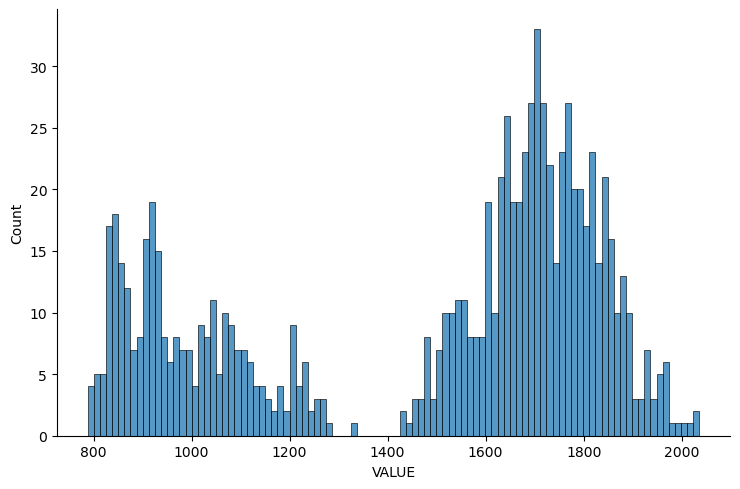

```
final_training_df_output_df_AvgAnnHrsWrk_ByAge.csv
```

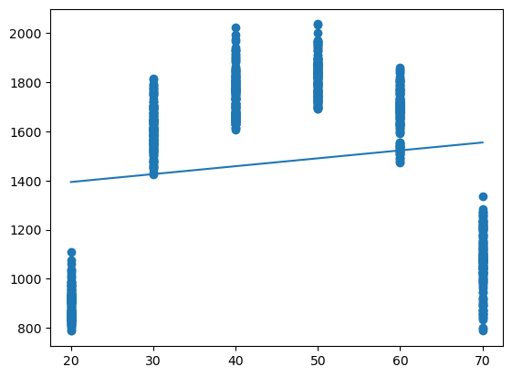

```
Done by Linear Regression
```

```python
dfa_to_cover = 0

dfa_Training_AvgAnnHrsWrk_To_Analysis.print_result(dfa_to_cover) # Print the result for each Characteristics.
dfa_Training_AvgAnnHrsWrk_To_Analysis.print_histogram(dfa_to_cover) # Print the histogram for each Characteristics.
dfa_Training_AvgAnnHrsWrk_To_Analysis.print_classifier(dfa_to_cover) # Print the possible classifier for each Characteristics.
```

Result for training set for 'Average annual hours worked' by Education level

```
final_training_df_output_df_AvgAnnHrsWrk_ByEducation.csv
                                   sum         mean    amin  median    amax  \
Characteristics
High school diploma and less  197099.0  1313.993333  1177.0  1299.5  1508.0
Trade certificate             239040.0  1593.600000  1390.0  1562.0  1904.0
University degree and higher  254326.0  1695.506667  1527.0  1698.5  1894.0

                              size
Characteristics
High school diploma and less   150
Trade certificate              150
University degree and higher   150
Overall,
Sum :  690465.0
Mean :  1534.3666666666666
Min/median/max : 1177.0 / 1557.0 / 1904.0
Standard Deviation :  183.0583179693777
Skewnewss :  -0.24125831672287715
Total size :  450

final_training_df_output_df_AvgAnnHrsWrk_ByEducation.csv
```

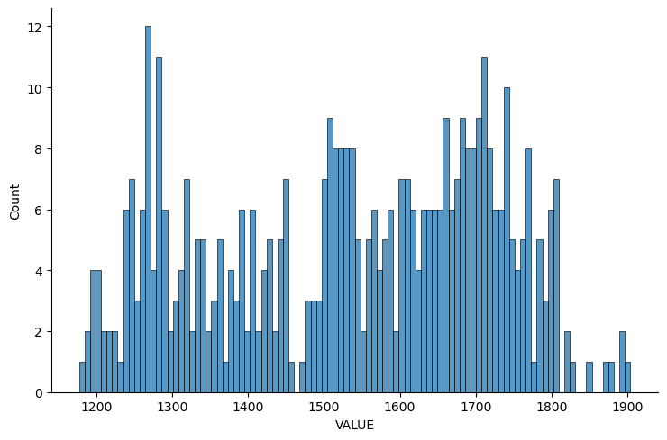

```
final_training_df_output_df_AvgAnnHrsWrk_ByEducation.csv
```

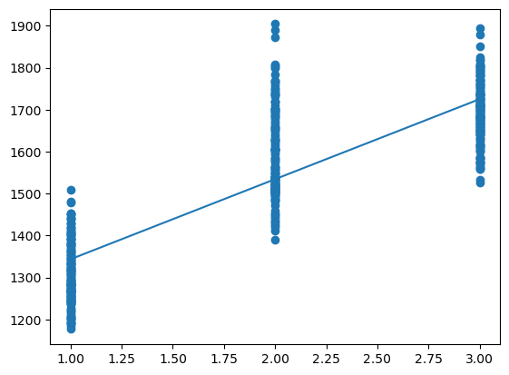

```
Done by Linear Regression
Higher the number, higher the education
```

```python
dfa_to_cover = 1

dfa_Training_AvgAnnHrsWrk_To_Analysis.print_result(dfa_to_cover) # Print the result for each Characteristics.
dfa_Training_AvgAnnHrsWrk_To_Analysis.print_histogram(dfa_to_cover) # Print the histogram for each Characteristics.
dfa_Training_AvgAnnHrsWrk_To_Analysis.print_classifier(dfa_to_cover) # Print the possible classifier for each Characteristics.
```

Result for training set for 'Average annual hours worked' by Gender group

```
final_training_df_output_df_AvgAnnHrsWrk_ByGender.csv
                       sum         mean    amin  median    amax  size
Characteristics
Female employees  230639.0  1537.593333  1412.0  1538.0  1698.0   150
Male employees    247348.0  1648.986667  1462.0  1647.5  1804.0   150
Overall,
Sum :  477987.0
Mean :  1593.29
Min/median/max : 1412.0 / 1590.5 / 1804.0
Standard Deviation :  90.55230109353012
Skewnewss :  0.2882947149239751
Total size :  300

final_training_df_output_df_AvgAnnHrsWrk_ByGender.csv
```

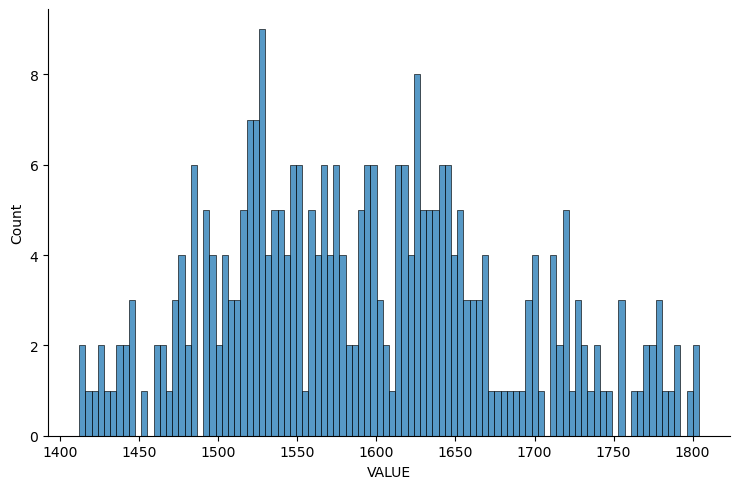

```
final_training_df_output_df_AvgAnnHrsWrk_ByGender.csv
```

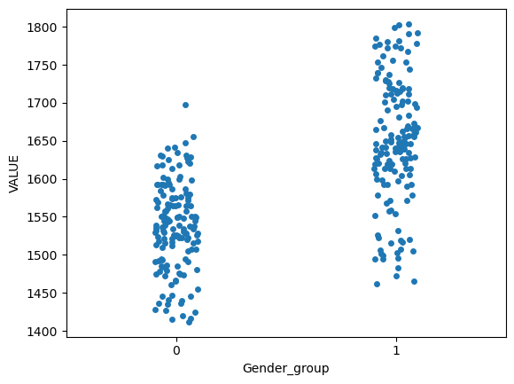

```
Done using Stripplot
[1, 0] = ['Male employees' 'Female employees']
```

```python
dfa_to_cover = 2

dfa_Training_AvgAnnHrsWrk_To_Analysis.print_result(dfa_to_cover) # Print the result for each Characteristics.
dfa_Training_AvgAnnHrsWrk_To_Analysis.print_histogram(dfa_to_cover) # Print the histogram for each Characteristics.
dfa_Training_AvgAnnHrsWrk_To_Analysis.print_classifier(dfa_to_cover) # Print the possible classifier for each Characteristics.
```

Result for training set for 'Average annual hours worked' by Immigrant status

```
final_training_df_output_df_AvgAnnHrsWrk_ByImmigrant.csv
                              sum         mean    amin  median    amax  size
Characteristics
Immigrant employees      238512.0  1590.080000  1400.0  1595.5  1765.0   150
Non-immigrant employees  235777.0  1571.846667  1438.0  1574.5  1699.0   150
Overall,
Sum :  474289.0
Mean :  1580.9633333333334
Min/median/max : 1400.0 / 1586.0 / 1765.0
Standard Deviation :  68.88252310193705
Skewnewss :  -0.29743141315518284
Total size :  300

final_training_df_output_df_AvgAnnHrsWrk_ByImmigrant.csv
```

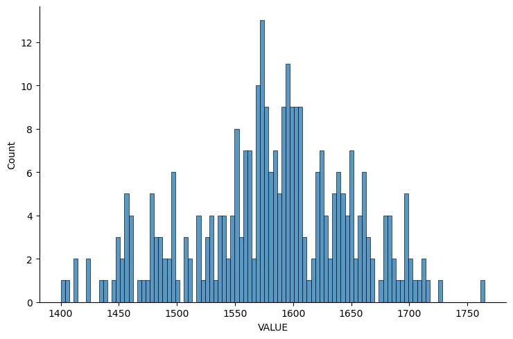

```
final_training_df_output_df_AvgAnnHrsWrk_ByImmigrant.csv
```

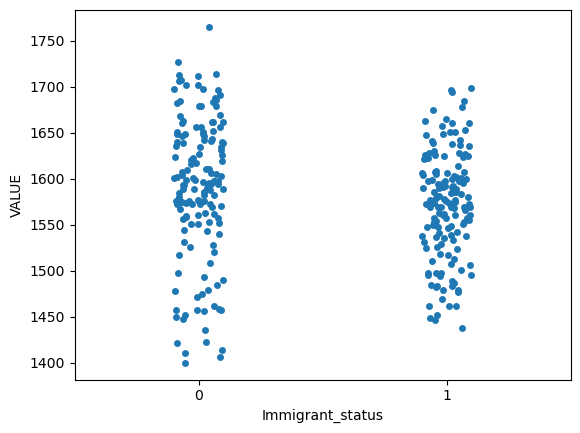

```
Done using Stripplot
[0, 1] = ['Immigrant employees' 'Non-immigrant employees']
```

```python
dfa_to_cover = 3

dfa_Training_AvgAnnHrsWrk_To_Analysis.print_result(dfa_to_cover) # Print the result for each Characteristics.
dfa_Training_AvgAnnHrsWrk_To_Analysis.print_histogram(dfa_to_cover) # Print the histogram for each Characteristics.
dfa_Training_AvgAnnHrsWrk_To_Analysis.print_classifier(dfa_to_cover) # Print the possible classifier for each Characteristics.
```

Result for training set for 'Average annual hours worked' by yearly

```
final_training_df_output_df_AvgAnnHrsWrk_ByAge.csv
```

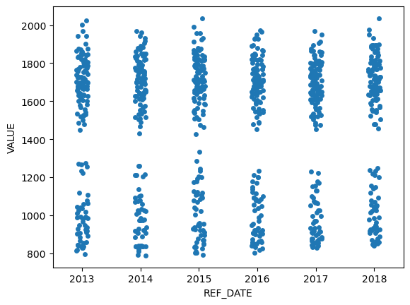

```
Done using Stripplot
```

```python
dfa_to_cover = 0

dfa_Training_AvgAnnHrsWrk_To_Analysis.print_byYearlyGraph('REF_DATE',dfa_to_cover) # Print the possible classifier based on Yearly only on Age group.
```

Result for training set for 'Average annual wages and salaries'

```python
# Export dataset to analysis

dfa_Training_AvgAnnWages_To_Analysis = df_Final_TrainingDataset_AvgAnnWages
dfa_Training_AvgAnnWages_To_Analysis = Final_Target_To_Analysis(dfa_Training_AvgAnnWages_To_Analysis, pd, np, pp, sns, df_Final_TrainingDataset_AvgAnnWages_Name)
```

Result for training set for 'Average annual wages and salaries' by Age group

```
final_training_df_output_df_AvgAnnWages_ByAge.csv
                             sum          mean     amin   median     amax  \
Characteristics
15 to 24 years         2201591.0  14677.273333   9944.0  14222.5  21671.0
25 to 34 years         5522502.0  36816.680000  27239.0  36902.0  49744.0
35 to 44 years         7437012.0  49580.080000  36021.0  49282.5  66133.0
45 to 54 years         8260471.0  55069.806667  37873.0  54568.0  74095.0
55 to 64 years         7654252.0  51028.346667  34578.0  50257.0  70393.0
65 years old and over  4791610.0  31944.066667  18687.0  30546.5  49820.0

                       size
Characteristics
15 to 24 years          150
25 to 34 years          150
35 to 44 years          150
45 to 54 years          150
55 to 64 years          150
65 years old and over   150
Overall,
Sum :  35867438.0
Mean :  39852.70888888889
Min/median/max : 9944.0 / 41086.0 / 74095.0
Standard Deviation :  15662.07774664399
Skewnewss :  -0.21004932759297887
Total size :  900

final_training_df_output_df_AvgAnnWages_ByAge.csv
```

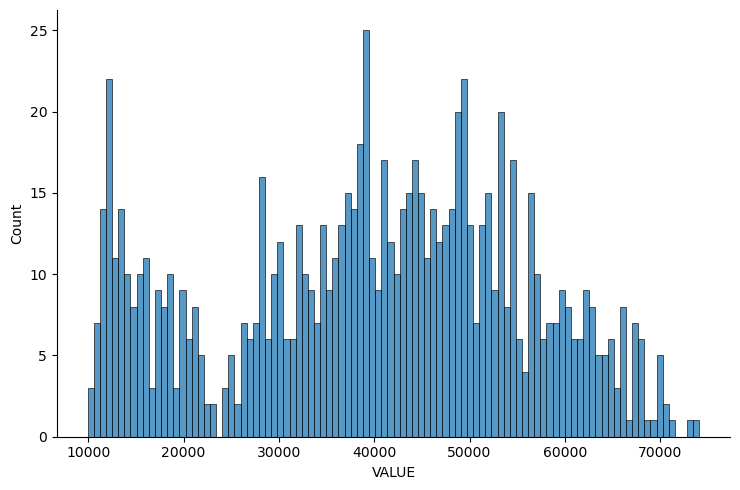

```
final_training_df_output_df_AvgAnnWages_ByAge.csv
```

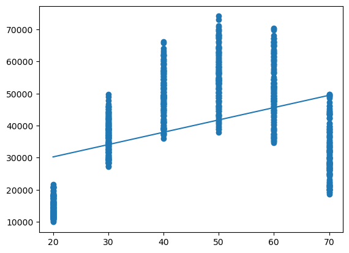

```
Done by Linear Regression
```

```python
dfa_to_cover = 0

dfa_Training_AvgAnnWages_To_Analysis.print_result(dfa_to_cover) # Print the result for each Characteristics.
dfa_Training_AvgAnnWages_To_Analysis.print_histogram(dfa_to_cover) # Print the histogram for each Characteristics.
dfa_Training_AvgAnnWages_To_Analysis.print_classifier(dfa_to_cover) # Print the possible classifier for each Characteristics.
```

Result for training set for 'Average annual wages and salaries' by Education level

```
final_training_df_output_df_AvgAnnWages_ByEducation.csv
                                    sum          mean     amin   median  \
Characteristics
High school diploma and less  4148328.0  27655.520000  17525.0  27352.5
Trade certificate             5961133.0  39740.886667  25690.0  38230.5
University degree and higher  7996089.0  53307.260000  38370.0  53039.0

                                 amax  size
Characteristics
High school diploma and less  39647.0   150
Trade certificate             69402.0   150
University degree and higher  68278.0   150
Overall,
Sum :  18105550.0
Mean :  40234.555555555555
Min/median/max : 17525.0 / 38514.0 / 69402.0
Standard Deviation :  12693.593488152565
Skewnewss :  0.40865383104454694
Total size :  450

final_training_df_output_df_AvgAnnWages_ByEducation.csv
```

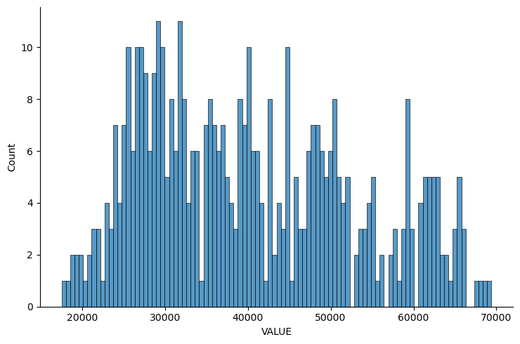

```
final_training_df_output_df_AvgAnnWages_ByEducation.csv
```

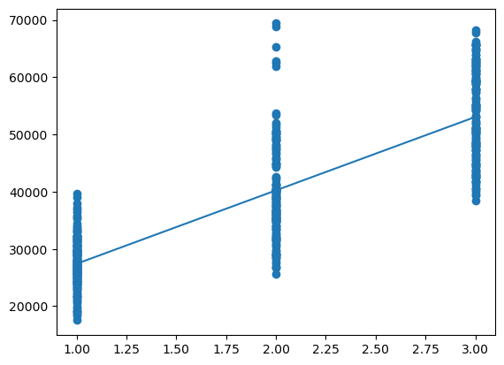

```
Done by Linear Regression
Higher the number, higher the education
```

```python
dfa_to_cover = 1

dfa_Training_AvgAnnWages_To_Analysis.print_result(dfa_to_cover) # Print the result for each Characteristics.
dfa_Training_AvgAnnWages_To_Analysis.print_histogram(dfa_to_cover) # Print the histogram for each Characteristics.
dfa_Training_AvgAnnWages_To_Analysis.print_classifier(dfa_to_cover) # Print the possible classifier for each Characteristics.
```

Result for training set for 'Average annual wages and salaries' by Gender group

```
final_training_df_output_df_AvgAnnWages_ByGender.csv
                        sum          mean     amin   median     amax  size
Characteristics
Female employees  5906780.0  39378.533333  28416.0  38342.5  54766.0   150
Male employees    7450496.0  49669.973333  32999.0  48723.5  68935.0   150
Overall,
Sum :  13357276.0
Mean :  44524.253333333334
Min/median/max : 28416.0 / 44535.5 / 68935.0
Standard Deviation :  9288.40366599605
Skewnewss :  0.4314732041122265
Total size :  300

final_training_df_output_df_AvgAnnWages_ByGender.csv
```

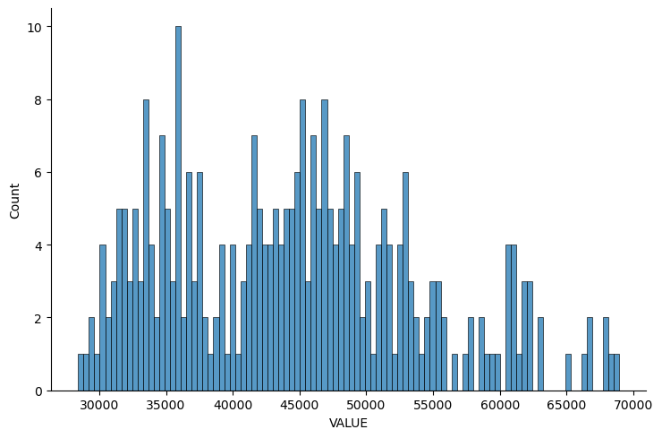

```
final_training_df_output_df_AvgAnnWages_ByGender.csv
```

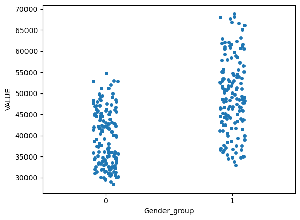

```
Done using Stripplot
[1, 0] = ['Male employees' 'Female employees']
```

```python
dfa_to_cover = 2

dfa_Training_AvgAnnWages_To_Analysis.print_result(dfa_to_cover) # Print the result for each Characteristics.
dfa_Training_AvgAnnWages_To_Analysis.print_histogram(dfa_to_cover) # Print the histogram for each Characteristics.
dfa_Training_AvgAnnWages_To_Analysis.print_classifier(dfa_to_cover) # Print the possible classifier for each Characteristics.
```

Result for training set for 'Average annual wages and salaries' by Immigrant status

```
final_training_df_output_df_AvgAnnWages_ByImmigrant.csv
                               sum          mean     amin   median     amax  \
Characteristics
Immigrant employees      6348960.0  42326.400000  28138.0  41305.0  58379.0
Non-immigrant employees  6473501.0  43156.673333  29871.0  42879.5  57089.0

                         size
Characteristics
Immigrant employees       150
Non-immigrant employees   150
Overall,
Sum :  12822461.0
Mean :  42741.53666666667
Min/median/max : 28138.0 / 42469.5 / 58379.0
Standard Deviation :  7477.527564330484
Skewnewss :  -0.008804076716501099
Total size :  300

final_training_df_output_df_AvgAnnWages_ByImmigrant.csv
```

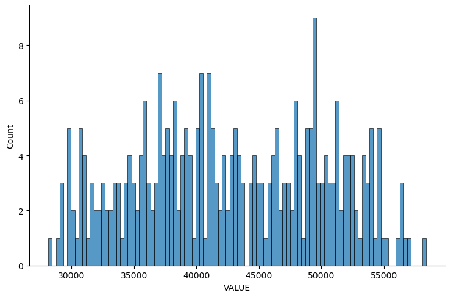

```
final_training_df_output_df_AvgAnnWages_ByImmigrant.csv
```

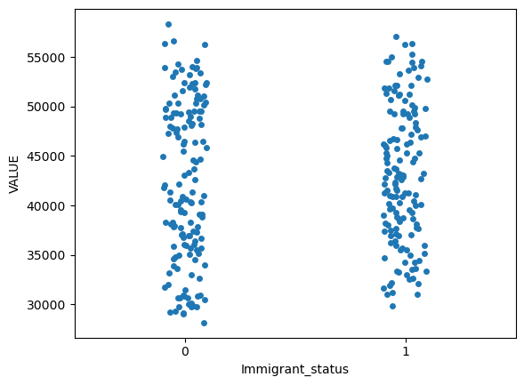

```
Done using Stripplot
[0, 1] = ['Immigrant employees' 'Non-immigrant employees']
```

```python
dfa_to_cover = 3

dfa_Training_AvgAnnWages_To_Analysis.print_result(dfa_to_cover) # Print the result for each Characteristics.
dfa_Training_AvgAnnWages_To_Analysis.print_histogram(dfa_to_cover) # Print the histogram for each Characteristics.
dfa_Training_AvgAnnWages_To_Analysis.print_classifier(dfa_to_cover) # Print the possible classifier for each Characteristics.
```

Result for training set for 'Average annual wages and salaries' by yearly

```
final_training_df_output_df_AvgAnnWages_ByAge.csv
```

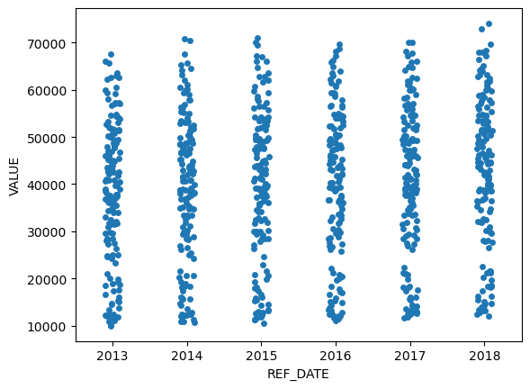

```
Done using Stripplot
```

```python
dfa_to_cover = 0

dfa_Training_AvgAnnWages_To_Analysis.print_byYearlyGraph('REF_DATE',dfa_to_cover) # Print the possible classifier based on Yearly only on Age group.
```

Result for training set for 'Average hourly wage'

```python
# Export dataset to analysis

dfa_Training_AvgHrsWages_To_Analysis = df_Final_TrainingDataset_AvgHrsWages
dfa_Training_AvgHrsWages_To_Analysis = Final_Target_To_Analysis(dfa_Training_AvgHrsWages_To_Analysis, pd, np, pp, sns, df_Final_TrainingDataset_AvgHrsWages_Name)
```

Result for training set for 'Average hourly wage' by Age group

```
final_training_df_output_df_AvgHrsWages_ByAge.csv
                           sum       mean   amin  median   amax  size
Characteristics
15 to 24 years         2433.56  16.223733  12.18  15.530  22.18   150
25 to 34 years         3433.97  22.893133  16.65  22.695  30.32   150
35 to 44 years         4236.72  28.244800  19.90  27.565  36.02   150
45 to 54 years         4519.64  30.130933  20.57  29.835  38.90   150
55 to 64 years         4552.73  30.351533  20.35  29.925  39.83   150
65 years old and over  4465.94  29.772933  18.37  29.040  43.83   150
Overall,
Sum :  23642.56
Mean :  26.26951111111111
Min/median/max : 12.18 / 26.39 / 43.83
Standard Deviation :  6.836752411691197
Skewnewss :  -0.0046761021580015785
Total size :  900

final_training_df_output_df_AvgHrsWages_ByAge.csv
```

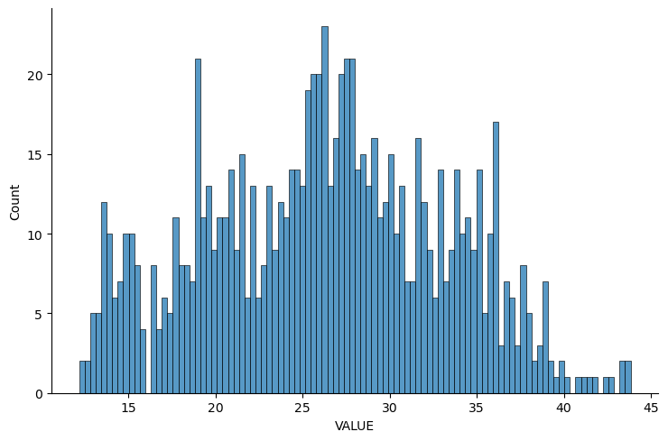

```
final_training_df_output_df_AvgHrsWages_ByAge.csv
```

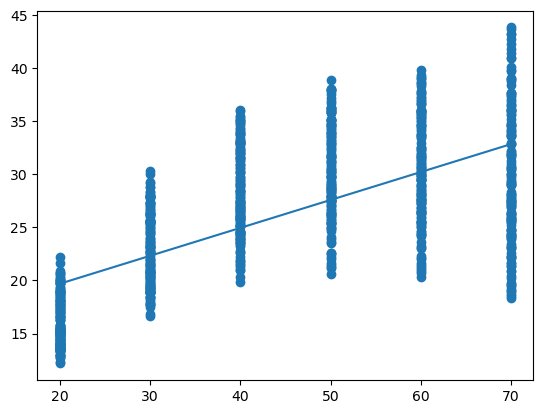

```
Done by Linear Regression
```

```python
dfa_to_cover = 0

dfa_Training_AvgHrsWages_To_Analysis.print_result(dfa_to_cover) # Print the result for each Characteristics.
dfa_Training_AvgHrsWages_To_Analysis.print_histogram(dfa_to_cover) # Print the histogram for each Characteristics.
dfa_Training_AvgHrsWages_To_Analysis.print_classifier(dfa_to_cover) # Print the possible classifier for each Characteristics.
```

Result for training set for 'Average hourly wage' by Education level

```
final_training_df_output_df_AvgHrsWages_ByEducation.csv
                                  sum     mean   amin  median   amax  size
Characteristics
High school diploma and less  3146.19  20.9746  14.70   21.16  26.81   150
Trade certificate             3716.88  24.7792  17.76   24.37  37.06   150
University degree and higher  4727.40  31.5160  21.47   30.84  41.36   150
Overall,
Sum :  11590.47
Mean :  25.7566
Min/median/max : 14.7 / 24.54 / 41.36
Standard Deviation :  5.896346495547523
Skewnewss :  0.6582168868606721
Total size :  450

final_training_df_output_df_AvgHrsWages_ByEducation.csv
```

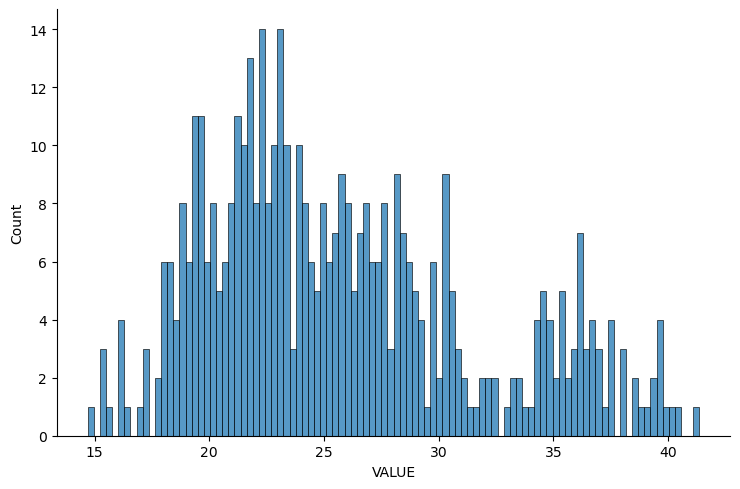

```
final_training_df_output_df_AvgHrsWages_ByEducation.csv
```

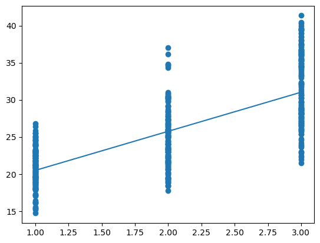

```
Done by Linear Regression
Higher the number, higher the education
```

```python
dfa_to_cover = 1

dfa_Training_AvgHrsWages_To_Analysis.print_result(dfa_to_cover) # Print the result for each Characteristics.
dfa_Training_AvgHrsWages_To_Analysis.print_histogram(dfa_to_cover) # Print the histogram for each Characteristics.
dfa_Training_AvgHrsWages_To_Analysis.print_classifier(dfa_to_cover) # Print the possible classifier for each Characteristics.
```

Result for training set for 'Average hourly wage' by Gender group

```
final_training_df_output_df_AvgHrsWages_ByGender.csv
                      sum       mean   amin  median   amax  size
Characteristics
Female employees  3835.41  25.569400  18.35  24.900  33.84   150
Male employees    4514.51  30.096733  20.18  29.625  40.06   150
Overall,
Sum :  8349.92
Mean :  27.833066666666667
Min/median/max : 18.35 / 27.545 / 40.06
Standard Deviation :  4.976384088427616
Skewnewss :  0.3231035192153794
Total size :  300

final_training_df_output_df_AvgHrsWages_ByGender.csv
```

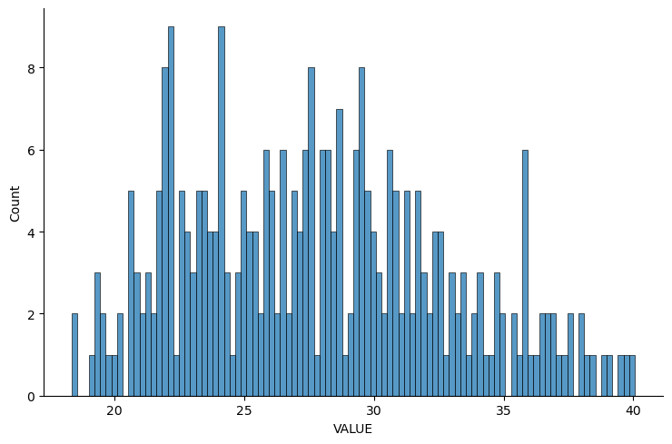

```
final_training_df_output_df_AvgHrsWages_ByGender.csv
```

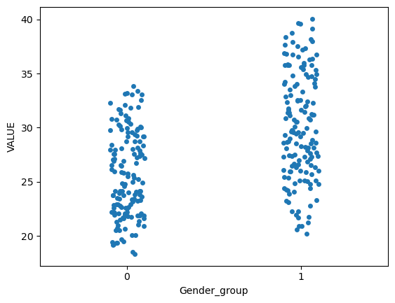

```
Done using Stripplot
[1, 0] = ['Male employees' 'Female employees']
```

```python
dfa_to_cover = 2

dfa_Training_AvgHrsWages_To_Analysis.print_result(dfa_to_cover) # Print the result for each Characteristics.
dfa_Training_AvgHrsWages_To_Analysis.print_histogram(dfa_to_cover) # Print the histogram for each Characteristics.
dfa_Training_AvgHrsWages_To_Analysis.print_classifier(dfa_to_cover) # Print the possible classifier for each Characteristics.
```

Result for training set for 'Average hourly wage' by Immigrant status

```
final_training_df_output_df_AvgHrsWages_ByImmigrant.csv
                             sum       mean   amin  median   amax  size
Characteristics
Immigrant employees      3983.72  26.558133  18.31  26.065  36.07   150
Non-immigrant employees  4115.40  27.436000  18.98  26.955  36.20   150
Overall,
Sum :  8099.120000000001
Mean :  26.99706666666667
Min/median/max : 18.31 / 26.8 / 36.2
Standard Deviation :  4.370814805299148
Skewnewss :  0.022394104021715048
Total size :  300

final_training_df_output_df_AvgHrsWages_ByImmigrant.csv
```

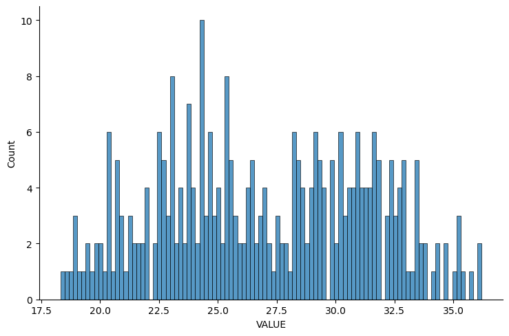

```
final_training_df_output_df_AvgHrsWages_ByImmigrant.csv
```

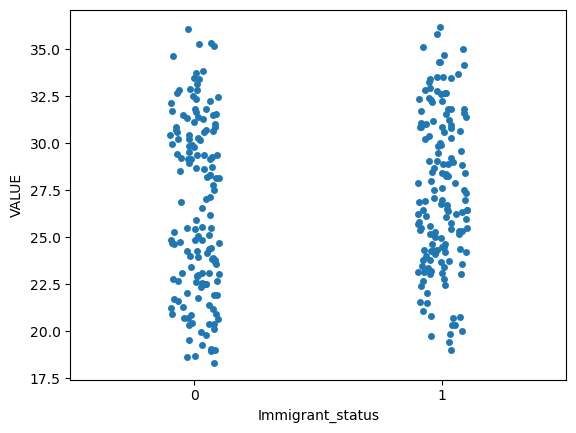

```
Done using Stripplot
[0, 1] = ['Immigrant employees' 'Non-immigrant employees']
```

```python
dfa_to_cover = 3

dfa_Training_AvgHrsWages_To_Analysis.print_result(dfa_to_cover) # Print the result for each Characteristics.
dfa_Training_AvgHrsWages_To_Analysis.print_histogram(dfa_to_cover) # Print the histogram for each Characteristics.
dfa_Training_AvgHrsWages_To_Analysis.print_classifier(dfa_to_cover) # Print the possible classifier for each Characteristics.
```

Result for training set for 'Average hourly wage' by yearly

```
final_training_df_output_df_AvgHrsWages_ByAge.csv
```

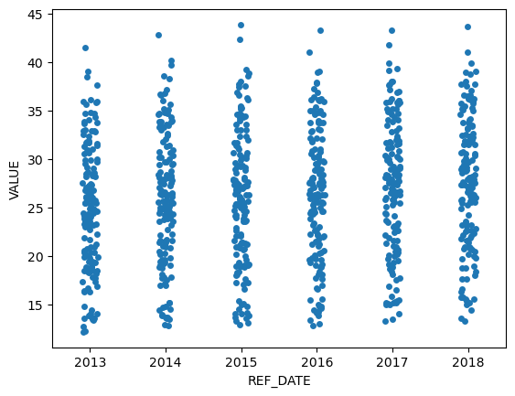

```
Done using Stripplot
```

```python
dfa_to_cover = 0

dfa_Training_AvgHrsWages_To_Analysis.print_byYearlyGraph('REF_DATE',dfa_to_cover) # Print the possible classifier based on Yearly only on Age group.
```

Result for training set for 'Average weekly hours worked'

```python
# Export dataset to analysis

dfa_Training_AvgWeekHrsWrked_To_Analysis = df_Final_TrainingDataset_AvgWeekHrsWrked
dfa_Training_AvgWeekHrsWrked_To_Analysis = Final_Target_To_Analysis(dfa_Training_AvgWeekHrsWrked_To_Analysis, pd, np, pp, sns, df_Final_TrainingDataset_AvgWeekHrsWrked_Name)
```